# Comparing Visualizations

# Intro

This post is inspired by a [discussion in LinkedIn](https://www.linkedin.com/posts/paulvanderlaken_think-twice-before-plotting-your-boxes-activity-6899369243398193152-63Y0) about the good and the ugly about boxplots vs. the scatter plots posted by [Paul van der Laken, PhD](https://www.linkedin.com/in/paulvanderlaken/) in which he cites an article by [Nick Desbarats](https://www.linkedin.com/in/nickdesbarats/) titled **“I’ve stopped using boxplots. Should you?”**, a very thought provoking piece that [you can read here](https://nightingaledvs.com/ive-stopped-using-box-plots-should-you/).

Even though I agree with the general idea that simpler is better, and you have to always think first in your audience and whether they would understand or not a plot, in my opinion there is no a *best type of plot* over other. A plot should be used with a purpose.

Another point against boxplots is that they are complex to understand, and you need people with statistical comprehension to read them. Which is true. Considering I work mainly with HR professionals and statistics is not our main strength, boxplots condense a lot of statistical information. So, why bother?

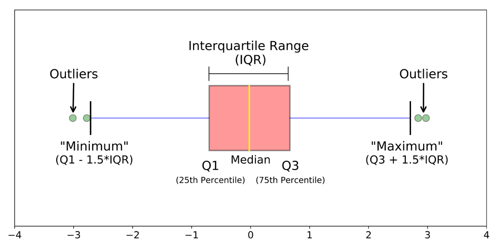

An explanation of all the information a boxplot provides (outliers, quartiles 1 and 3, median)

In my opinion, even if you are making a pie chart or a bar chart, you always have to explain what the visualization is saying, specially if you are using some other type of chart people is no familiar with. Don’t assume your audience will interpret the plot the same way you intended to.

[figure not shown]

Don’t assume the user will know how to read the plot

```r
# Libraries & Data ----
library(tidyverse)
library(funModeling)

# Data
salaries <- read.csv("https://raw.githubusercontent.com/r4hr/r4hr_introduccion_dplyr/main/Datos/encuesta_sueldos.csv",
                     sep = ",",
                     encoding = "UTF-8")
```